# Case Study 1

GEOG-3440

Case studies provide you with an opportunity to use relevant workflows or real world data to answer Earth science questions. These are typically written in story problem form so humor me by jumping into character! Take time to carefully read and consider how to solve each problem.

## **Flow Control**

This case study focuses on flow control, alternating, and branching. While there are multiple ways to solve these problems, you should try to use `for` loops, `if`/`else` statements, or other iterative functions to arrive at your answers.

**For submission**, provide a well-formatted **html** document in RMarkdown (see instructions at the end of the document). Do not include unnecessary or cluttered code, instead be sure you clearly provide the information requested at the end of each section in an organized manner (under *Submit*). I would suggest using a simple *R script* to work on these questions, then clean your code and reformat your results in an RMarkdown document to produce the final report.

### **Part 1. Snow Science**

The USDA would like you to find a way to estimate snow depth over time using **only** the *precipitation accumulation* and *air temperature*, as these sensors are the easiest and cheapest to install across the region. You will calculate (model) hourly snow depth and compare it to the recorded (observed) snow depth at the station to get a sense of how well your simple model works.

Lucky that you remember several conversations with Dr. Olson’s about snow science! Ultimately, snow depth is a product of **three things**, 1) new snow accumulation, 2) snow melt, and 3) compaction or settling. Each of these processes is described in the next section.

**Important snow information:**

- The average **density** of falling snow is typically 5-10%, with average density in Utah being ~8.5% (round up to 9%). Using $\text{snow (in)} = \frac{water (in)}{density}$ you can calculate the amount of snow you would expect given a known amount of incoming moisture. For example, if 1 inch of water fell with a density of 10%, you would get $\frac{1 in}{0.1} = \text{10 in}$ of snow. While colder temperatures lead to lower snow densities, a constant value can provide a reasonable estimate. You will use the equation above (with 9% density) and increases in precipitation accumulation to estimate any new snow added for a given hour.
- Snow **melts** by absorbing energy from the sun, atmosphere, and nearby surroundings. While not perfect, air temperature can be used as a proxy of energy in a system. Degree-day (DD) models are frequently used to estimate the amount of melt based on the temperature range. This can be expressed as $\text{DD} = Mf * (Ta - Ts)$, where *Mf* is melt factor, *Ta* is the air temperature (deg F), and *Ts* is the temperature of the snow (assume freezing or 32 deg F). Melt factors are calibrated based on location and time of year, however, a value of 0.05 in. of snow hr<sup>-1</sup> degF<sup>-1</sup> can be used for our case. If melt occurs, use the the equation above to determine the amount of melt, and subtract it from the current snow depth amount.
- Finally, over time snow will **settle**. This process is called sintering, which causes snow to become more dense as bonds are formed between snow crystals. This process causes the snow to settle and the overall depth to decrease as the snow ages. Settling rates vary dramatically but sometimes follow a decay curve, meaning that fresh snow settles rapidly but slows down over time. For your model, assume a constant settling rate of 0.1 in hr<sup>-1</sup>. Meaning that this amount should be subtracted from the snow depth each hour.

To accomplish this task, you will need to *prepare your data*, then *build a workflow* to accomplish the task described above

**1) Prepare your Data**

- Rename columns for ease of use
- Convert your datetime column into the appropriate format
- QA/QC your snow depth data, raw data often contains errors that must either be corrected or filtered out. You need to keep the data hourly, so an easy solution for now is to convert any values above a certain threshold to `NA`. Plot the data to investigate which value to use
- Keep in mind that `NA` values exist in your data and are an import type of data, rather than removing these, you will need to build your code to account for this type of data

**2) Build a Workflow**

There are many ways to tackle this problem and many directions to go when building a workflow. For this first case study, I will give you one solution that allows you to explore iteration and alteration with `for` loops and `if` statements. Use the following steps to guide you:

1. Define a new, blank column to store your new modeled snow depth (e.g., `df_brighton$mod_depth1 <- NA`), then set the first value to match the initial observed snow depth value in the dataset (i.e. 32 in)
2. You have cumulative precipitation but need to know if snowfall occurred. You can use the `diff()` function to create a new column that shows if there was a positive increase in precipitation accumulation (e.g., `df_brighton$snowfall <- ...`). This amount will be used, with your density parameter to estimate the amount of new snow that will accumulate on your snowpack (see section above on snow density). You’ll notice that `diff` returns a vector that is shorter than other columns in your data frame, because this is a change between hours, you can add a `0` at the beginning (e.g., `c(0, diff(...))`). Ignore snowfall or precipitation values that are less than 1.
3. Now you can iterate through each hour to determine how snow depth is changing over time. Write a `for` loop to iterate through each hour and use `if`, `if else`, and `else` statements to determine if snow was added or if melt occured based on your temperature (*note there are NA values*). Indexing can be useful to access and add the modeled snow depth values to your data frame. Consider the order of steps in your code, for example, the starting value at each hour will be the same as the previous hour, then you will have steps that *might* add to the existing snow amount, that *might* melt some of the existing snow amount, and *will always* settle some amount of snow. It might make sense to start your `for` loop at the second time step (e.g., `for (i in 2:...){`).
4. Add `print()` statements throughout to keep you aware of what is going on in your code. For example, at the start of the `for` loop, you might have `print(paste("Modeling snow depth for:", df_brighton$date[i]))`
5. Consider writing your code in a way that allows you to easily modify parameters like the melt factor and settling rate without too much effort.
6. When plotting your results, it can be helpful to adjust the y-axis limits in case the modeled values are quite a bit higher and lower than the observed values (e.g., after plotting observed `plot(depth~..., type = 'l', ylim = c(25, 50)`) add the modeled `plot(mod_depth1~..., col = 'green')`)

*Feel free to read more about [snow science](https://nsidc.org/learn/parts-cryosphere/snow/science-snow) and [snowpack properties](https://www.hec.usace.army.mil/confluence/hmsdocs/hmstrm/snow-accumulation-and-melt/snow-properties) in your own time!*

### **Part 2. Mineralogy**

You are working as a geologist analyzing the mineral content of volcanic rock samples taken from different locations around the world. 25 samples have been processed and the composition percentages of 3 key minerals (quartz, alkali feldspar, and plagioclase) have been calculated and normalized.

You have been commissioned to conduct the preliminary analysis on this dataset using a classification commonly used to distinguish fine-grained igneous rocks based on the percentages of the above mineral compositions.

Run the following code below to load the sample matrix into your R session. The data is organized as **Q**uartz, **A**lkali Feldspar, **P**lagioclase in columns 1-3 respectively.

```r
rock_comp <- matrix(c(43.18, 22.49, 34.33,
                      8.19, 34.61, 57.20,
                      27.28, 55.12, 17.60,
                      62.95, 16.55, 20.50,
                      47.83, 11.77, 40.39,
                      58.92, 6.50, 34.58,
                      18.42, 21.35, 60.23,
                      18.38, 15.16, 66.47,
                      19.41, 42.25, 38.34,
                      65.16, 1.91, 32.93,
                      29.43, 24.08, 46.49,
                      25.32, 36.72, 37.96,
                      11.66, 46.38, 41.96,
                      40.35, 23.41, 36.24,
                      52.34, 38.90, 8.76,
                      2.54, 67.07, 30.39,
                      55.56, 39.70, 4.74,
                      9.32, 20.84, 69.84,
                      39.24, 27.34, 33.42,
                      25.82, 40.90, 33.28,
                      31.66, 36.99, 31.34,
                      47.52, 27.74, 24.74,
                      33.00, 60.59, 6.41,
                      45.33, 7.94, 46.73,
                      14.68, 35.34, 49.99),
                     nrow=25, ncol=3, byrow = TRUE)
```

*Tip: you can convert this to a data frame with `as.data.frame()` but can also accomplish the task by keeping it as a matrix*

**Use the simplified IUGS tertiary QAP diagram below** to distinguish between the fine-grained igneous rock samples.

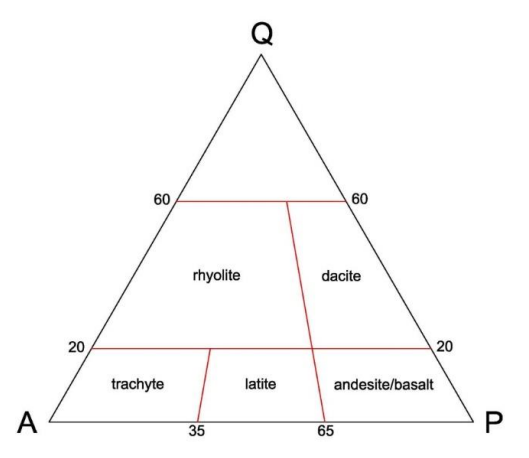

Source: Modified from Le Maitre et al., 2002

*Ternary diagrams use three variables to plot conditions or identity. Use the example above to observe how the location of a point may be mapped using the Q- Quartz, A- Alkali Feldspar, and P- Plagioclase percentages*

**IMPORTANT tips for classifying your samples**

1. Use the mineral percentage values shown in the figure above to distinguish between rock types. Note that the data is provided as a total percentage of each mineral relative to all three (QAP), whereas some values/lines are shown as relative percentages between only two of the minerals. Continue reading to understand this concept better.
2. One key aspect of these diagrams is the *weighted ratio*. In other words, rather than determining the location of each sample based on total percentages of each mineral, you will classify rock types in a stepwise fashion by using one percentage then the re-weighted percentages of the other two to further refine your decision. For example, once the Q location (vertical) is determined on the graph with logic (above X and/or below Y), you can then re-weight your A and P percentage values for that sample to determine where the sample fits horizontally on the ternary plot. In other words, after determining Q, you will recalculate your values for A and P as new percentages based on the two previous values (e.g. with A=10% and P=25%, your new $\text{A} = \frac{10}{10 + 25} = \text{28%}$ ). This can be done because the vertical red lines, although slightly skewed, represent the relative percentage between A & P; not to be confused with total percentage of the three distinct minerals (QAP) given in the data.
3. Use a `for` loop to iterate through each sample and place `if`, `if else`, and `else` statements to help refine the classification. Again, while there are other ways to solve this, it is good practice using these functions.
4. Any samples with greater than 60% Quartz content can be labeled as `NA` or “Unknown”.

#### **Submit - Part 2**

> 1. Provide your code solution to classify rock sample data based on the simplified QAP diagram above.
> 2. Create a barplot or pie plot showing the number or percentage of each type of volcanic rock in these samples. Be sure to spend time creating quality final figures for full points.
> 3. (optional) You can use the [Ternary](https://cran.r-project.org/web/packages/Ternary/vignettes/Ternary.html) package in R to plot these points!

#### **Final Submission**

Upload a single, organized **html file** written in **R Markdown** showing **questions, code solutions, and responses**. Be sure to support your responses with code and result outputs.

*Please reach out if you have any questions!*

References:

Le Maitre, R.W., Streckeisen, A., Zanettin, M.J., Le Bas, M.J., Bonin, B., Bateman, P., Bellieni, G., Dudel, A., Efremova, S., Keller, J., Lameyre, J., Sabine, P.A., Schmid, R., Sørenson, H., and Wooley, A.R. (eds.), 2002, Igneous Rocks: A Classification and Glossary of Terms: Cambridge University Press, Cambridge, U.K.